```python
import os
import numpy as np
import pandas as pd
import matplotlib.pyplot as plt
import tensorflow as tf
from tensorflow import keras
from tensorflow.keras.utils import to_categorical
from sklearn.model_selection import train_test_split
import cv2
```

# IMPORTING DATA

```python
# Define dataset path (modify this to match your actual folder structure)
DATASET_PATH = "/Users/gunturuvarsha/Downloads/CNN Ship Classification/"
TRAIN_PATH = os.path.join(DATASET_PATH, "train")

# Check if paths are correct
print(os.listdir(TRAIN_PATH))
```

```
['.DS_Store', 'images', 'train.csv']
```

```python
print("Train Set:", os.listdir(TRAIN_PATH))
```

```
Train Set: ['.DS_Store', 'images', 'train.csv']
```

```python
IMAGE_PATH = "/Users/gunturuvarsha/Downloads/CNN Ship Classification/train/images"
CSV_PATH = os.path.join(TRAIN_PATH, "train.csv")
```

```python
import pandas as pd

df = pd.read_csv(CSV_PATH)
df.head()
```

|  | image | category |
| --- | --- | --- |
| 0 | 2823080.jpg | 1 |
| 1 | 2870024.jpg | 1 |
| 2 | 2662125.jpg | 2 |
| 3 | 2900420.jpg | 3 |
| 4 | 2804883.jpg | 2 |

```python
df.count()#data count
```

```
image       6252
category    6252
dtype: int64
```

```python
df.image.value_counts().unique() #Check for duplicates
```

```
array([1])
```

```python
# percentage of class distribution in the dataset
(df.value_counts('category')/6252)*100
```

```
category
1    33.909149
5    19.465771
2    18.666027
3    14.651312
4    13.307742
Name: count, dtype: float64
```

Category 1 is the most common at 33.91%, while Category 4 is the least at 13.31%. Categories 2, 3, and 5 are more balanced but still vary. This slight imbalance may bias the model toward dominant classes.

```python
IMAGE_SIZE = (128, 128)  # Resize images
images = []
labels = []
NUM_CLASSES = df['category'].nunique()  # Count unique labels
print(NUM_CLASSES)
```

```
5
```

Lists to load the images and labels. The images will be then mapped to their respective category. Rezing images for consisency and compatibiity with the model, reducing computational load and enabling the model to converge faster whilt retaining crucial image features. Resizing the images to 128*128.

```python
print(IMAGE_PATH)
```

```
/Users/gunturuvarsha/Downloads/CNN Ship Classification/train/images
```

```python
print(os.listdir(IMAGE_PATH)[:10])
```

```
['2870091.jpg', '2860282.jpg', '2894465.jpg', '2784253.jpg', '2853890.jpg', '2898539.jpg', '644577.jpg', '2856056.jpg', '2792357.jpg', '2904710.jpg']
```

# Preprocessing Images

```python
# Load and preprocess images
def load_images():
    for index, row in df.iterrows():
        img_name = row['image']
        label = row['category']-1 # Adjust label to start from 0

        img_path = os.path.join(IMAGE_PATH, img_name)

        if not os.path.exists(img_path):
            print(f"Warning: {img_path} not found, skipping...")
            continue

        # Read image using OpenCV
        img = cv2.imread(img_path)
        if img is None:
            print(f"Warning: Could not read {img_path}, skipping...")
            continue

        # Convert BGR to RGB
        img = cv2.cvtColor(img, cv2.COLOR_BGR2RGB)

        # Resize image
        img = cv2.resize(img, IMAGE_SIZE)

        # Check if the image is blank
        if np.all(img == img[0, 0, :]):  # Check if all pixels are the same
            print(f"Warning: {img_path} is blank, skipping...")
            continue

        # Normalize pixels to [0,1] range
        img = img / 255.0

        images.append(img)
        labels.append(label)

# Load images
load_images()

# Convert to NumPy arrays
X = np.array(images)
y = np.array(labels)
```

Reading image file names and retrieving their labels. Each image is loaded using OpenCV, converted from BGR to RGB, and resized to a fixed (128, 128) dimension. The script filters out missing, unreadable, or blank images to maintain data quality. Finally, pixel values are normalized to the [0,1] range.

```python
print(f"Shape of X: {X.shape}")
```

```
Shape of X: (6252, 128, 128, 3)
```

```
Training set: (5001, 128, 128, 3), Testing set: (1251, 128, 128, 3)
```

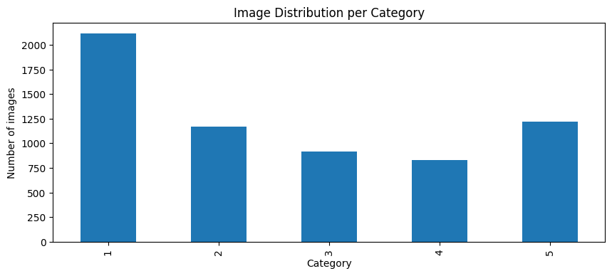

[figure not shown]

```python
# One-hot encode labels. # use mapping
y = to_categorical(y, num_classes=NUM_CLASSES)

# Split into train and test sets
X_train, X_test, y_train, y_test = train_test_split(X, y, test_size=0.2, stratify=y, random_state=42)


print(f"Training set: {X_train.shape}, Testing set: {X_test.shape}")

# Display category-wise image distribution
plt.figure(figsize=(10, 4))
df['category'].value_counts().sort_index().plot(kind='bar')
plt.xlabel('Category')
plt.ylabel('Number of images')
plt.title('Image Distribution per Category')
plt.show()

# Display sample images
plt.figure(figsize=(15, 5))
for i in range(15):  # Show up to 15 images
    plt.subplot(3, 5, i + 1)
    plt.imshow(X_train[i])
    plt.axis('off')
plt.suptitle("Sample Training Images", fontsize=15)
plt.show()
```

[figure not shown]

```python
#image augmentation
from tensorflow.keras.preprocessing.image import ImageDataGenerator
# Define data augmentation parameters
datagen = ImageDataGenerator(
    rotation_range=20, # Randomly rotate images
    width_shift_range=0.2, # Randomly shift images horizontally
    height_shift_range=0.2, # Randomly shift images vertically
    shear_range=0.2,# Randomly shear images
    zoom_range=0.2,# Randomly zoom in/out
    channel_shift_range=0.2, # Randomly change brightness
    horizontal_flip=True,# Randomly flip images
    fill_mode='nearest'# Fill in new pixels
)
# Display augmented images
plt.figure(figsize=(15, 5))
for i in range(15):  # Show up to 15 images
    plt.subplot(3, 5, i + 1)
    augmented_image = datagen.random_transform(X_train[i])
    plt.imshow(augmented_image)
    plt.axis('off')
plt.suptitle("Augmented Training Images", fontsize=15)
plt.show()
```

## Image Augumentation

To increase training dataset diversity.

- Rotation, shifting, shearing, and zooming modify the perspective.
- Channel shift adjusts brightness levels.
- Horizontal flipping helps the model recognize mirrored patterns.
- Fill mode handles missing pixels after transformations.

Visualizing 15 random images to see the data augumentation applied. This will help in the robustness, reduce overfitting and help generalise the model well.

# BUILDING THE CNN MODEL

## MODEL 1

- Convolutional Blocks: Three blocks of Conv2D, BatchNorm, MaxPooling, and Dropout layers for feature extraction.
- Regularization: Dropout and L2 regularization to reduce overfitting.
- Compilation: Uses Adam optimizer, categorical cross-entropy loss, and tracks accuracy, precision, and recall.
- Early Stopping: Stops training if validation loss doesn’t improve for 10 epochs.
- Learning Rate Reduction: Reduces LR if no improvement in 3 epochs.
- Class Weights: Balances class distribution to prevent bias.
- Visualization: Plots accuracy and loss curves to analyze performance

[output not shown]

```
2025-03-30 03:38:46.971070: I tensorflow/core/grappler/optimizers/custom_graph_optimizer_registry.cc:117] Plugin optimizer for device_type GPU is enabled.
```

```
157/157 ━━━━━━━━━━━━━━━━━━━━ 31s 156ms/step - accuracy: 0.3758 - loss: 2.2083 - precision: 0.4055 - recall: 0.2924 - val_accuracy: 0.1463 - val_loss: 2.2888 - val_precision: 0.1649 - val_recall: 0.1263 - learning_rate: 0.0010
157/157 ━━━━━━━━━━━━━━━━━━━━ 21s 135ms/step - accuracy: 0.5240 - loss: 1.5263 - precision: 0.5776 - recall: 0.4280 - val_accuracy: 0.3205 - val_loss: 1.7347 - val_precision: 0.5993 - val_recall: 0.1375 - learning_rate: 0.0010
157/157 ━━━━━━━━━━━━━━━━━━━━ 21s 134ms/step - accuracy: 0.6387 - loss: 1.1398 - precision: 0.7031 - recall: 0.5550 - val_accuracy: 0.4948 - val_loss: 1.6461 - val_precision: 0.5830 - val_recall: 0.4069 - learning_rate: 0.0010
157/157 ━━━━━━━━━━━━━━━━━━━━ 21s 134ms/step - accuracy: 0.6983 - loss: 0.9432 - precision: 0.7532 - recall: 0.6363 - val_accuracy: 0.5739 - val_loss: 1.2509 - val_precision: 0.6428 - val_recall: 0.4804 - learning_rate: 0.0010
157/157 ━━━━━━━━━━━━━━━━━━━━ 23s 144ms/step - accuracy: 0.7486 - loss: 0.8431 - precision: 0.8016 - recall: 0.6933 - val_accuracy: 0.6579 - val_loss: 1.2962 - val_precision: 0.7113 - val_recall: 0.5987 - learning_rate: 0.0010
157/157 ━━━━━━━━━━━━━━━━━━━━ 23s 143ms/step - accuracy: 0.7937 - loss: 0.7817 - precision: 0.8270 - recall: 0.7415 - val_accuracy: 0.6986 - val_loss: 1.0453 - val_precision: 0.7479 - val_recall: 0.6355 - learning_rate: 0.0010
157/157 ━━━━━━━━━━━━━━━━━━━━ 21s 136ms/step - accuracy: 0.8102 - loss: 0.7628 - precision: 0.8523 - recall: 0.7738 - val_accuracy: 0.5875 - val_loss: 1.5180 - val_precision: 0.6443 - val_recall: 0.5460 - learning_rate: 0.0010
157/157 ━━━━━━━━━━━━━━━━━━━━ 21s 136ms/step - accuracy: 0.8379 - loss: 0.6847 - precision: 0.8775 - recall: 0.8049 - val_accuracy: 0.6507 - val_loss: 1.2782 - val_precision: 0.7358 - val_recall: 0.6011 - learning_rate: 0.0010
157/157 ━━━━━━━━━━━━━━━━━━━━ 21s 135ms/step - accuracy: 0.8608 - loss: 0.6918 - precision: 0.8896 - recall: 0.8341 - val_accuracy: 0.7570 - val_loss: 1.0495 - val_precision: 0.7874 - val_recall: 0.7194 - learning_rate: 0.0010
157/157 ━━━━━━━━━━━━━━━━━━━━ 21s 136ms/step - accuracy: 0.8782 - loss: 0.6592 - precision: 0.9005 - recall: 0.8496 - val_accuracy: 0.7650 - val_loss: 0.9714 - val_precision: 0.8051 - val_recall: 0.7266 - learning_rate: 5.0000e-04
157/157 ━━━━━━━━━━━━━━━━━━━━ 21s 136ms/step - accuracy: 0.9157 - loss: 0.4959 - precision: 0.9302 - recall: 0.8983 - val_accuracy: 0.7666 - val_loss: 0.9475 - val_precision: 0.8035 - val_recall: 0.7386 - learning_rate: 5.0000e-04
157/157 ━━━━━━━━━━━━━━━━━━━━ 21s 136ms/step - accuracy: 0.9322 - loss: 0.4295 - precision: 0.9416 - recall: 0.9211 - val_accuracy: 0.7898 - val_loss: 0.8853 - val_precision: 0.8153 - val_recall: 0.7690 - learning_rate: 5.0000e-04
157/157 ━━━━━━━━━━━━━━━━━━━━ 21s 136ms/step - accuracy: 0.9278 - loss: 0.4203 - precision: 0.9386 - recall: 0.9151 - val_accuracy: 0.7370 - val_loss: 1.1983 - val_precision: 0.7589 - val_recall: 0.7194 - learning_rate: 5.0000e-04
157/157 ━━━━━━━━━━━━━━━━━━━━ 21s 136ms/step - accuracy: 0.9310 - loss: 0.4285 - precision: 0.9415 - recall: 0.9195 - val_accuracy: 0.7770 - val_loss: 0.9377 - val_precision: 0.8027 - val_recall: 0.7610 - learning_rate: 5.0000e-04
157/157 ━━━━━━━━━━━━━━━━━━━━ 22s 137ms/step - accuracy: 0.9486 - loss: 0.4031 - precision: 0.9583 - recall: 0.9387 - val_accuracy: 0.7778 - val_loss: 0.9578 - val_precision: 0.7992 - val_recall: 0.7570 - learning_rate: 5.0000e-04
157/157 ━━━━━━━━━━━━━━━━━━━━ 21s 136ms/step - accuracy: 0.9527 - loss: 0.3862 - precision: 0.9583 - recall: 0.9437 - val_accuracy: 0.7978 - val_loss: 0.8380 - val_precision: 0.8231 - val_recall: 0.7738 - learning_rate: 2.5000e-04
157/157 ━━━━━━━━━━━━━━━━━━━━ 22s 138ms/step - accuracy: 0.9651 - loss: 0.3215 - precision: 0.9706 - recall: 0.9602 - val_accuracy: 0.8169 - val_loss: 0.8116 - val_precision: 0.8307 - val_recall: 0.8042 - learning_rate: 2.5000e-04
157/157 ━━━━━━━━━━━━━━━━━━━━ 22s 137ms/step - accuracy: 0.9685 - loss: 0.2925 - precision: 0.9717 - recall: 0.9621 - val_accuracy: 0.8114 - val_loss: 0.8086 - val_precision: 0.8293 - val_recall: 0.8002 - learning_rate: 2.5000e-04
157/157 ━━━━━━━━━━━━━━━━━━━━ 21s 136ms/step - accuracy: 0.9732 - loss: 0.2698 - precision: 0.9759 - recall: 0.9692 - val_accuracy: 0.8066 - val_loss: 0.8250 - val_precision: 0.8183 - val_recall: 0.7922 - learning_rate: 2.5000e-04
157/157 ━━━━━━━━━━━━━━━━━━━━ 22s 142ms/step - accuracy: 0.9723 - loss: 0.2558 - precision: 0.9737 - recall: 0.9699 - val_accuracy: 0.8082 - val_loss: 0.8565 - val_precision: 0.8230 - val_recall: 0.7994 - learning_rate: 2.5000e-04
157/157 ━━━━━━━━━━━━━━━━━━━━ 22s 139ms/step - accuracy: 0.9679 - loss: 0.2559 - precision: 0.9718 - recall: 0.9629 - val_accuracy: 0.8018 - val_loss: 0.8281 - val_precision: 0.8227 - val_recall: 0.7826 - learning_rate: 2.5000e-04
157/157 ━━━━━━━━━━━━━━━━━━━━ 22s 139ms/step - accuracy: 0.9678 - loss: 0.2404 - precision: 0.9710 - recall: 0.9657 - val_accuracy: 0.8090 - val_loss: 0.8319 - val_precision: 0.8177 - val_recall: 0.7994 - learning_rate: 1.2500e-04
157/157 ━━━━━━━━━━━━━━━━━━━━ 22s 139ms/step - accuracy: 0.9800 - loss: 0.2132 - precision: 0.9805 - recall: 0.9783 - val_accuracy: 0.8209 - val_loss: 0.8342 - val_precision: 0.8340 - val_recall: 0.8114 - learning_rate: 1.2500e-04
157/157 ━━━━━━━━━━━━━━━━━━━━ 22s 140ms/step - accuracy: 0.9796 - loss: 0.1983 - precision: 0.9811 - recall: 0.9788 - val_accuracy: 0.8249 - val_loss: 0.7709 - val_precision: 0.8395 - val_recall: 0.8114 - learning_rate: 1.2500e-04
157/157 ━━━━━━━━━━━━━━━━━━━━ 22s 141ms/step - accuracy: 0.9855 - loss: 0.1803 - precision: 0.9871 - recall: 0.9833 - val_accuracy: 0.8177 - val_loss: 0.7964 - val_precision: 0.8309 - val_recall: 0.8050 - learning_rate: 1.2500e-04
157/157 ━━━━━━━━━━━━━━━━━━━━ 22s 141ms/step - accuracy: 0.9856 - loss: 0.1750 - precision: 0.9872 - recall: 0.9847 - val_accuracy: 0.8201 - val_loss: 0.7809 - val_precision: 0.8314 - val_recall: 0.8082 - learning_rate: 1.2500e-04
```

[output cut: 13 more lines]

```
WARNING:absl:You are saving your model as an HDF5 file via `model.save()` or `keras.saving.save_model(model)`. This file format is considered legacy. We recommend using instead the native Keras format, e.g. `model.save('my_model.keras')` or `keras.saving.save_model(model, 'my_model.keras')`.
```

```
40/40 ━━━━━━━━━━━━━━━━━━━━ 1s 24ms/step - accuracy: 0.8172 - loss: 0.7514 - precision: 0.8305 - recall: 0.8097
Validation Accuracy: 0.82, Precision: 0.84, Recall: 0.81
```

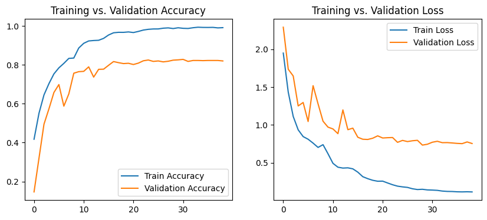

```python
from tensorflow.keras.metrics import Precision, Recall
from sklearn.utils import class_weight
from tensorflow.keras.callbacks import EarlyStopping
# Define CNN model
model = keras.Sequential([
    keras.layers.Input(shape=(128, 128, 3)),

    # Block 1
    keras.layers.Conv2D(32, (3,3), activation='relu'),
    keras.layers.BatchNormalization(),
    keras.layers.MaxPooling2D((2,2)),
    keras.layers.Dropout(0.2),

    # Block 2
    keras.layers.Conv2D(64, (3,3), activation='relu'),
    keras.layers.BatchNormalization(),
    keras.layers.MaxPooling2D((2,2)),
    keras.layers.Dropout(0.3),

    # Block 3
    keras.layers.Conv2D(128, (3,3), activation='relu'),
    keras.layers.BatchNormalization(),
    keras.layers.MaxPooling2D((2,2)),

    keras.layers.Flatten(),

    # Dense
    keras.layers.Dense(128, activation='relu', kernel_regularizer=keras.regularizers.l2(0.001)),
    keras.layers.BatchNormalization(),
    keras.layers.Dropout(0.5),

    keras.layers.Dense(NUM_CLASSES, activation='softmax')
])

# Compile model
model.compile(optimizer='adam', loss='categorical_crossentropy', metrics=['accuracy',Precision(), Recall()])


early_stopping = EarlyStopping(
    monitor='val_loss',
    patience=10,
    min_delta=0.001,
    restore_best_weights=True
)

reduce_lr = keras.callbacks.ReduceLROnPlateau(factor=0.5, patience=3) #try removing this nd see the difference

# If y_train is one-hot encoded
y_train_classes = np.argmax(y_train, axis=1)

# Then compute class weights
class_weights = class_weight.compute_class_weight(
    class_weight='balanced',
    classes=np.unique(y_train_classes),
    y=y_train_classes
)
class_weight_dic = dict(enumerate(class_weights))


# Train model with Early Stopping
history = model.fit( X_train, y_train, epochs=50, batch_size=32, validation_data=(X_test, y_test), callbacks=[early_stopping, reduce_lr],class_weight=class_weight_dic)

# Save trained model
model.save("cnn_model_1.h5")

# Evaluate model performance
val_loss, val_acc, val_precision, val_recall = model.evaluate(X_test, y_test)
print(f"Validation Accuracy: {val_acc:.2f}, Precision: {val_precision:.2f}, Recall: {val_recall:.2f}")

# Visualize training results
plt.figure(figsize=(10, 4))
plt.subplot(1, 2, 1)
plt.plot(history.history['accuracy'], label='Train Accuracy')
plt.plot(history.history['val_accuracy'], label='Validation Accuracy')
plt.legend()
plt.title('Training vs. Validation Accuracy')

plt.subplot(1, 2, 2)
plt.plot(history.history['loss'], label='Train Loss')
plt.plot(history.history['val_loss'], label='Validation Loss')
plt.legend()
plt.title('Training vs. Validation Loss')
plt.show()
```

### MODEL ARCHITECTURE

The CNN consists of three convolutional blocks followed by dense layers.

#### Convolutional Blocks

Each block extracts features from images through the following layers:

- `Conv2D` (Convolution Layer): Detects patterns like edges, textures, and shapes.
- `BatchNormalization`: Normalizes activations to stabilize learning.
- `MaxPooling2D`: Reduces spatial size (downsampling) while keeping key features.
- `Dropout`: Prevents overfitting by randomly deactivating neurons.

#### Layers Overview

- `Block 1`: 32 filters → Small features, Dropout (20%)
- `Block 2`: 64 filters → More complex patterns, Dropout (30%)
- `Block 3`: 128 filters → Even deeper features

After these blocks, the extracted features are flattened into a 1D vector.

#### Fully connected layer

- Dense Layer (128 neurons, ReLU): Learns high-level relationships between features.
- BatchNormalization: Stabilizes training.
- Dropout (50%): Prevents overfitting.
- Dense Output Layer:
- `NUM_CLASSES` neurons with softmax activation (for multi-class classification).

#### Compilation & Loss Function

- Adam Optimizer: Adaptive learning for faster convergence.
- Categorical Crossentropy: Used for multi-class classification.
- Metrics:
  - Accuracy: Measures correct predictions.
  - Precision: Focuses on how many predicted positives are correct.
  - Recall: Measures how many actual positives were detected.

#### Training with early stopping, class balancing, LR adjustment

- Stops training if validation loss doesn’t improve for 10 epochs. Prevents overfitting by avoiding unnecessary training.
- Reduces learning rate if the model stops improving. Prevents oscillation in training.
- Assigns higher weight to underrepresented classes to prevent bias. Ensures fair learning across all categories.

### Model Training

- Epochs: 50 (adjusted dynamically with early stopping).
- Batch Size: 32 (good balance between speed and stability).
- Validation Data: Helps monitor generalization.
- Callbacks: Early stopping & learning rate adjustment.

Saving the model as `cnn_model_1.h5` and then evaluating accuracy, precision, and recall on test data. The model performance is then visualised using `Training Vs Validation Accuracy and Loss`.

```
40/40 ━━━━━━━━━━━━━━━━━━━━ 1s 23ms/step
40/40 ━━━━━━━━━━━━━━━━━━━━ 1s 19ms/step
```

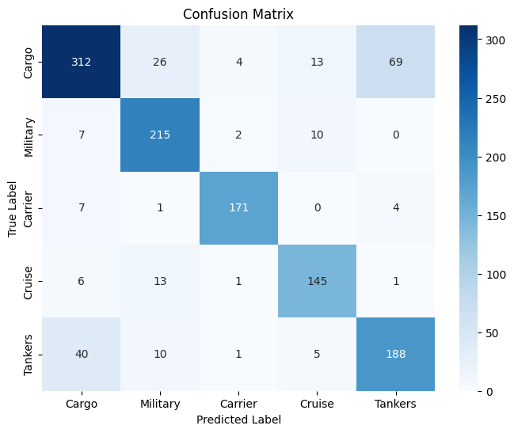

```
Classification Report:
              precision    recall  f1-score   support

           0       0.84      0.74      0.78       424
           1       0.81      0.92      0.86       234
           2       0.96      0.93      0.94       183
           3       0.84      0.87      0.86       166
           4       0.72      0.77      0.74       244

    accuracy                           0.82      1251
   macro avg       0.83      0.85      0.84      1251
weighted avg       0.83      0.82      0.82      1251
```

```python
import seaborn as sns
from sklearn.metrics import f1_score, classification_report,confusion_matrix
y_pred = model.predict(X_test)
y_pred_labels = np.argmax(y_pred, axis=1)
y_true_labels = np.argmax(y_test, axis=1)

# Define class names based on your labels
CLASS_NAMES = ["Cargo", "Military", "Carrier", "Cruise", "Tankers"]

# Get true labels and predicted labels
y_true_labels = np.argmax(y_test, axis=1)  # Convert one-hot encoding to class labels
y_pred_labels = np.argmax(model.predict(X_test), axis=1)  # Predict and get class labels

# Compute confusion matrix
cm = confusion_matrix(y_true_labels, y_pred_labels)

# Plot confusion matrix using Seaborn
plt.figure(figsize=(8,6))
sns.heatmap(cm, annot=True, fmt="d", cmap="Blues", xticklabels=CLASS_NAMES, yticklabels=CLASS_NAMES)

# Add labels and title
plt.xlabel("Predicted Label")
plt.ylabel("True Label")
plt.title("Confusion Matrix")
plt.show()

report = classification_report(y_true_labels, y_pred_labels)
print("Classification Report:")
print(report)
```

Evaluating the CNN model by generating predictions on the test set and comparing them with actual labels. Computing a confusion matrix to visualize misclassifications and a classification report to measure precision, recall, and F1-score. The confusion matrix is plotted using Seaborn, highlighting class-wise performance. This helps in identifying strengths and weaknesses of the model for each ship category.

```python
model.summary()
```

```
Model: "sequential"
```

```
┏━━━━━━━━━━━━━━━━━━━━━━━━━━━━━━━━━┳━━━━━━━━━━━━━━━━━━━━━━━━┳━━━━━━━━━━━━━━━┓
┃ Layer (type)                    ┃ Output Shape           ┃       Param # ┃
┡━━━━━━━━━━━━━━━━━━━━━━━━━━━━━━━━━╇━━━━━━━━━━━━━━━━━━━━━━━━╇━━━━━━━━━━━━━━━┩
│ conv2d (Conv2D)                 │ (None, 126, 126, 32)   │           896 │
├─────────────────────────────────┼────────────────────────┼───────────────┤
│ batch_normalization             │ (None, 126, 126, 32)   │           128 │
│ (BatchNormalization)            │                        │               │
├─────────────────────────────────┼────────────────────────┼───────────────┤
│ max_pooling2d (MaxPooling2D)    │ (None, 63, 63, 32)     │             0 │
├─────────────────────────────────┼────────────────────────┼───────────────┤
│ dropout (Dropout)               │ (None, 63, 63, 32)     │             0 │
├─────────────────────────────────┼────────────────────────┼───────────────┤
│ conv2d_1 (Conv2D)               │ (None, 61, 61, 64)     │        18,496 │
├─────────────────────────────────┼────────────────────────┼───────────────┤
│ batch_normalization_1           │ (None, 61, 61, 64)     │           256 │
│ (BatchNormalization)            │                        │               │
├─────────────────────────────────┼────────────────────────┼───────────────┤
│ max_pooling2d_1 (MaxPooling2D)  │ (None, 30, 30, 64)     │             0 │
├─────────────────────────────────┼────────────────────────┼───────────────┤
│ dropout_1 (Dropout)             │ (None, 30, 30, 64)     │             0 │
├─────────────────────────────────┼────────────────────────┼───────────────┤
│ conv2d_2 (Conv2D)               │ (None, 28, 28, 128)    │        73,856 │
├─────────────────────────────────┼────────────────────────┼───────────────┤
│ batch_normalization_2           │ (None, 28, 28, 128)    │           512 │
│ (BatchNormalization)            │                        │               │
├─────────────────────────────────┼────────────────────────┼───────────────┤
│ max_pooling2d_2 (MaxPooling2D)  │ (None, 14, 14, 128)    │             0 │
├─────────────────────────────────┼────────────────────────┼───────────────┤
│ flatten (Flatten)               │ (None, 25088)          │             0 │
├─────────────────────────────────┼────────────────────────┼───────────────┤
│ dense (Dense)                   │ (None, 128)            │     3,211,392 │
├─────────────────────────────────┼────────────────────────┼───────────────┤
│ batch_normalization_3           │ (None, 128)            │           512 │
│ (BatchNormalization)            │                        │               │
├─────────────────────────────────┼────────────────────────┼───────────────┤
│ dropout_2 (Dropout)             │ (None, 128)            │             0 │
├─────────────────────────────────┼────────────────────────┼───────────────┤
│ dense_1 (Dense)                 │ (None, 5)              │           645 │
└─────────────────────────────────┴────────────────────────┴───────────────┘
```

```
 Total params: 9,918,673 (37.84 MB)
```

```
 Trainable params: 3,305,989 (12.61 MB)
```

```
 Non-trainable params: 704 (2.75 KB)
```

```
 Optimizer params: 6,611,980 (25.22 MB)
```

## MODEL2 - Using a pre-trained model

```
79/79 ━━━━━━━━━━━━━━━━━━━━ 32s 271ms/step - accuracy: 0.6591 - loss: 1.3612 - precision_1: 0.6735 - recall_1: 0.6513 - val_accuracy: 0.4804 - val_loss: 9.9034 - val_precision_1: 0.4804 - val_recall_1: 0.4804 - learning_rate: 0.0010
79/79 ━━━━━━━━━━━━━━━━━━━━ 14s 180ms/step - accuracy: 0.8541 - loss: 0.4634 - precision_1: 0.8622 - recall_1: 0.8463 - val_accuracy: 0.4980 - val_loss: 12.9244 - val_precision_1: 0.4984 - val_recall_1: 0.4964 - learning_rate: 0.0010
79/79 ━━━━━━━━━━━━━━━━━━━━ 14s 180ms/step - accuracy: 0.8876 - loss: 0.3448 - precision_1: 0.8906 - recall_1: 0.8836 - val_accuracy: 0.5316 - val_loss: 10.3520 - val_precision_1: 0.5316 - val_recall_1: 0.5316 - learning_rate: 0.0010
79/79 ━━━━━━━━━━━━━━━━━━━━ 15s 182ms/step - accuracy: 0.8883 - loss: 0.3638 - precision_1: 0.8926 - recall_1: 0.8872 - val_accuracy: 0.4748 - val_loss: 13.7303 - val_precision_1: 0.4748 - val_recall_1: 0.4748 - learning_rate: 0.0010
79/79 ━━━━━━━━━━━━━━━━━━━━ 15s 186ms/step - accuracy: 0.9231 - loss: 0.2178 - precision_1: 0.9293 - recall_1: 0.9212 - val_accuracy: 0.6827 - val_loss: 4.9544 - val_precision_1: 0.6832 - val_recall_1: 0.6827 - learning_rate: 5.0000e-04
79/79 ━━━━━━━━━━━━━━━━━━━━ 15s 183ms/step - accuracy: 0.9465 - loss: 0.1543 - precision_1: 0.9489 - recall_1: 0.9436 - val_accuracy: 0.5420 - val_loss: 8.9650 - val_precision_1: 0.5433 - val_recall_1: 0.5420 - learning_rate: 5.0000e-04
79/79 ━━━━━━━━━━━━━━━━━━━━ 15s 192ms/step - accuracy: 0.9530 - loss: 0.1342 - precision_1: 0.9550 - recall_1: 0.9513 - val_accuracy: 0.5795 - val_loss: 7.9929 - val_precision_1: 0.5800 - val_recall_1: 0.5795 - learning_rate: 5.0000e-04
79/79 ━━━━━━━━━━━━━━━━━━━━ 15s 184ms/step - accuracy: 0.9536 - loss: 0.1376 - precision_1: 0.9557 - recall_1: 0.9522 - val_accuracy: 0.6563 - val_loss: 7.3228 - val_precision_1: 0.6552 - val_recall_1: 0.6531 - learning_rate: 5.0000e-04
79/79 ━━━━━━━━━━━━━━━━━━━━ 15s 188ms/step - accuracy: 0.9743 - loss: 0.0827 - precision_1: 0.9754 - recall_1: 0.9742 - val_accuracy: 0.7106 - val_loss: 4.9271 - val_precision_1: 0.7106 - val_recall_1: 0.7106 - learning_rate: 2.5000e-04
79/79 ━━━━━━━━━━━━━━━━━━━━ 15s 184ms/step - accuracy: 0.9775 - loss: 0.0510 - precision_1: 0.9783 - recall_1: 0.9769 - val_accuracy: 0.6539 - val_loss: 6.2703 - val_precision_1: 0.6536 - val_recall_1: 0.6531 - learning_rate: 2.5000e-04
79/79 ━━━━━━━━━━━━━━━━━━━━ 15s 185ms/step - accuracy: 0.9882 - loss: 0.0358 - precision_1: 0.9884 - recall_1: 0.9881 - val_accuracy: 0.7474 - val_loss: 3.7186 - val_precision_1: 0.7490 - val_recall_1: 0.7466 - learning_rate: 2.5000e-04
79/79 ━━━━━━━━━━━━━━━━━━━━ 15s 184ms/step - accuracy: 0.9822 - loss: 0.0388 - precision_1: 0.9828 - recall_1: 0.9820 - val_accuracy: 0.7298 - val_loss: 3.9676 - val_precision_1: 0.7316 - val_recall_1: 0.7298 - learning_rate: 2.5000e-04
79/79 ━━━━━━━━━━━━━━━━━━━━ 15s 185ms/step - accuracy: 0.9936 - loss: 0.0191 - precision_1: 0.9936 - recall_1: 0.9935 - val_accuracy: 0.7898 - val_loss: 2.9560 - val_precision_1: 0.7917 - val_recall_1: 0.7898 - learning_rate: 2.5000e-04
79/79 ━━━━━━━━━━━━━━━━━━━━ 15s 186ms/step - accuracy: 0.9936 - loss: 0.0156 - precision_1: 0.9951 - recall_1: 0.9936 - val_accuracy: 0.8409 - val_loss: 1.9876 - val_precision_1: 0.8416 - val_recall_1: 0.8409 - learning_rate: 2.5000e-04
79/79 ━━━━━━━━━━━━━━━━━━━━ 15s 187ms/step - accuracy: 0.9950 - loss: 0.0149 - precision_1: 0.9950 - recall_1: 0.9950 - val_accuracy: 0.8361 - val_loss: 1.9768 - val_precision_1: 0.8388 - val_recall_1: 0.8361 - learning_rate: 2.5000e-04
79/79 ━━━━━━━━━━━━━━━━━━━━ 15s 188ms/step - accuracy: 0.9922 - loss: 0.0192 - precision_1: 0.9923 - recall_1: 0.9921 - val_accuracy: 0.8473 - val_loss: 1.7374 - val_precision_1: 0.8479 - val_recall_1: 0.8465 - learning_rate: 2.5000e-04
79/79 ━━━━━━━━━━━━━━━━━━━━ 15s 189ms/step - accuracy: 0.9866 - loss: 0.0363 - precision_1: 0.9869 - recall_1: 0.9865 - val_accuracy: 0.8449 - val_loss: 1.8908 - val_precision_1: 0.8462 - val_recall_1: 0.8441 - learning_rate: 2.5000e-04
79/79 ━━━━━━━━━━━━━━━━━━━━ 15s 189ms/step - accuracy: 0.9858 - loss: 0.0535 - precision_1: 0.9858 - recall_1: 0.9857 - val_accuracy: 0.8537 - val_loss: 1.8469 - val_precision_1: 0.8550 - val_recall_1: 0.8529 - learning_rate: 2.5000e-04
79/79 ━━━━━━━━━━━━━━━━━━━━ 15s 190ms/step - accuracy: 0.9834 - loss: 0.0653 - precision_1: 0.9838 - recall_1: 0.9834 - val_accuracy: 0.7842 - val_loss: 2.9338 - val_precision_1: 0.7842 - val_recall_1: 0.7842 - learning_rate: 2.5000e-04
79/79 ━━━━━━━━━━━━━━━━━━━━ 15s 191ms/step - accuracy: 0.9901 - loss: 0.0289 - precision_1: 0.9906 - recall_1: 0.9897 - val_accuracy: 0.8529 - val_loss: 1.8665 - val_precision_1: 0.8526 - val_recall_1: 0.8505 - learning_rate: 1.2500e-04
```

[output cut: 27 more lines]

```
WARNING:absl:You are saving your model as an HDF5 file via `model.save()` or `keras.saving.save_model(model)`. This file format is considered legacy. We recommend using instead the native Keras format, e.g. `model.save('my_model.keras')` or `keras.saving.save_model(model, 'my_model.keras')`.
```

```
40/40 ━━━━━━━━━━━━━━━━━━━━ 4s 77ms/step - accuracy: 0.9041 - loss: 0.9028 - precision_1: 0.9041 - recall_1: 0.9041
Validation Accuracy: 0.91, Precision: 0.91, Recall: 0.91
```

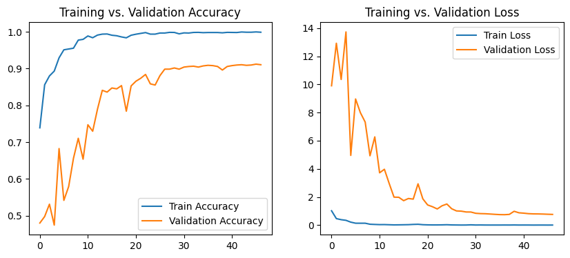

```
40/40 ━━━━━━━━━━━━━━━━━━━━ 6s 104ms/step
Classification Report:
              precision    recall  f1-score   support

           0       0.90      0.86      0.88       424
           1       0.94      0.97      0.96       234
           2       0.98      0.97      0.98       183
           3       0.90      0.98      0.94       166
           4       0.84      0.83      0.84       244

    accuracy                           0.91      1251
   macro avg       0.91      0.92      0.92      1251
weighted avg       0.91      0.91      0.91      1251
```

```python
# Load Pretrained Model (MobileNetV2)
base_model = keras.applications.MobileNetV2(
    input_shape=(128, 128, 3), include_top=False, weights="imagenet"
)
base_model.trainable = False  # Freeze base model layers

# Define the Model
model1 = keras.Sequential([
    base_model,
    keras.layers.GlobalAveragePooling2D(),
    keras.layers.BatchNormalization(),
    keras.layers.Dense(256, activation='relu'),
    keras.layers.Dropout(0.5),
    keras.layers.Dense(NUM_CLASSES, activation='softmax')
])

for layer in base_model.layers[-30:]:
    layer.trainable = True

# Compile Model
model1.compile(optimizer='adam',
              loss='categorical_crossentropy',
              metrics=['accuracy', Precision(), Recall()])



# Train Model
history = model1.fit(
    X_train, y_train, batch_size=64, epochs=50, validation_data=(X_test, y_test), callbacks=[early_stopping, reduce_lr], class_weight=class_weight_dic
)

model1.save("cnn_model_2.h5")

# Evaluate model performance
val_loss, val_acc, val_precision, val_recall = model1.evaluate(X_test, y_test)
print(f"Validation Accuracy: {val_acc:.2f}, Precision: {val_precision:.2f}, Recall: {val_recall:.2f}")

# Visualize training results
plt.figure(figsize=(10, 4))
plt.subplot(1, 2, 1)
plt.plot(history.history['accuracy'], label='Train Accuracy')
plt.plot(history.history['val_accuracy'], label='Validation Accuracy')
plt.legend()
plt.title('Training vs. Validation Accuracy')

plt.subplot(1, 2, 2)
plt.plot(history.history['loss'], label='Train Loss')
plt.plot(history.history['val_loss'], label='Validation Loss')
plt.legend()
plt.title('Training vs. Validation Loss')
plt.show()


y_pred = model1.predict(X_test)
y_pred_labels = np.argmax(y_pred, axis=1)
y_true_labels = np.argmax(y_test, axis=1)

report = classification_report(y_true_labels, y_pred_labels)
print("Classification Report:")
print(report)
```

Transfer learning using MobileNetV2, a lightweight convolutional neural network (CNN) that is pretrained on the ImageNet dataset.

### Loading the Pretrained Model (MobileNetV2)

- `MobileNetV2` is loaded with pretrained weights from `ImageNet`.
- The include_top=False option removes the original classification head, allowing us to add a custom classifier.
- The model is frozen initially (base_model.trainable = False) to retain the learned feature extraction layers.

### Building the Custom Classifier

- Global Average Pooling (GAP): Replaces fully connected layers, reducing parameters and overfitting.
- Batch Normalization: Stabilizes activations, improving training efficiency.
- Dense Layer (256 neurons, ReLU): Learns high-level patterns for ship classification.
- Dropout (50%): Prevents overfitting by randomly deactivating neurons during training.
- Output Layer: Uses softmax activation for multi-class classification, predicting probabilities for each ship category.

### Fine-tuning the Last 30 Layers

- Initially, MobileNetV2 was frozen to use its pretrained knowledge.
- Now, the last 30 layers are unfrozen, allowing fine-tuning for ship-specific features.

### Compiling the Model

- Optimizer: adam (Adaptive Moment Estimation) dynamically adjusts learning rates.
- Loss Function: categorical_crossentropy, ideal for multi-class classification.
- Metrics: accuracy, precision, and recall to measure classification performance.

### Training the Model

- Batch size: 64, meaning 64 images are processed per iteration.
- Epochs: 50, but training stops early if no improvement is detected.
- Validation Data: Helps monitor performance on unseen data.
- Callbacks:
  - early_stopping: Stops training if validation loss stops improving.
  - reduce_lr: Lowers the learning rate if progress slows.
- Class Weights: Adjusts for class imbalance to ensure underrepresented classes are learned properly.

### Saving and Evaluating the Model

The mdoel is saved in `cnn_model_2.h5`.  
Evaluating the CNN model by generating predictions on the test set and comparing them with actual labels. Computing a confusion matrix to visualize misclassifications and a classification report to measure precision, recall, and F1-score. The confusion matrix is plotted using Seaborn, highlighting class-wise performance. This helps in identifying strengths and weaknesses of the model for each ship category.

```python
model1.summary()
```

```
Model: "sequential_1"
```

```
┏━━━━━━━━━━━━━━━━━━━━━━━━━━━━━━━━━┳━━━━━━━━━━━━━━━━━━━━━━━━┳━━━━━━━━━━━━━━━┓
┃ Layer (type)                    ┃ Output Shape           ┃       Param # ┃
┡━━━━━━━━━━━━━━━━━━━━━━━━━━━━━━━━━╇━━━━━━━━━━━━━━━━━━━━━━━━╇━━━━━━━━━━━━━━━┩
│ mobilenetv2_1.00_128            │ (None, 4, 4, 1280)     │     2,257,984 │
│ (Functional)                    │                        │               │
├─────────────────────────────────┼────────────────────────┼───────────────┤
│ global_average_pooling2d        │ (None, 1280)           │             0 │
│ (GlobalAveragePooling2D)        │                        │               │
├─────────────────────────────────┼────────────────────────┼───────────────┤
│ batch_normalization_4           │ (None, 1280)           │         5,120 │
│ (BatchNormalization)            │                        │               │
├─────────────────────────────────┼────────────────────────┼───────────────┤
│ dense_2 (Dense)                 │ (None, 256)            │       327,936 │
├─────────────────────────────────┼────────────────────────┼───────────────┤
│ dropout_3 (Dropout)             │ (None, 256)            │             0 │
├─────────────────────────────────┼────────────────────────┼───────────────┤
│ dense_3 (Dense)                 │ (None, 5)              │         1,285 │
└─────────────────────────────────┴────────────────────────┴───────────────┘
```

```
 Total params: 6,308,689 (24.07 MB)
```

```
 Trainable params: 1,858,181 (7.09 MB)
```

```
 Non-trainable params: 734,144 (2.80 MB)
```

```
 Optimizer params: 3,716,364 (14.18 MB)
```

```
40/40 ━━━━━━━━━━━━━━━━━━━━ 2s 54ms/step
40/40 ━━━━━━━━━━━━━━━━━━━━ 2s 54ms/step
```

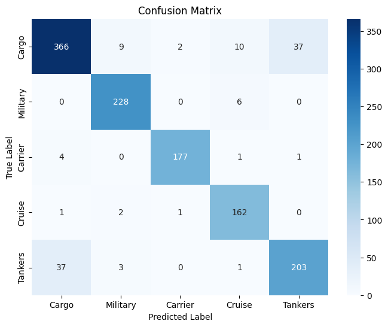

```python
import seaborn as sns
from sklearn.metrics import f1_score, classification_report,confusion_matrix
y_pred = model1.predict(X_test)
y_pred_labels = np.argmax(y_pred, axis=1)
y_true_labels = np.argmax(y_test, axis=1)

# Define class names based on your labels
CLASS_NAMES = ["Cargo", "Military", "Carrier", "Cruise", "Tankers"]

# Get true labels and predicted labels
y_true_labels = np.argmax(y_test, axis=1)  # Convert one-hot encoding to class labels
y_pred_labels = np.argmax(model1.predict(X_test), axis=1)  # Predict and get class labels

# Compute confusion matrix
cm = confusion_matrix(y_true_labels, y_pred_labels)

# Plot confusion matrix using Seaborn
plt.figure(figsize=(8,6))
sns.heatmap(cm, annot=True, fmt="d", cmap="Blues", xticklabels=CLASS_NAMES, yticklabels=CLASS_NAMES)

# Add labels and title
plt.xlabel("Predicted Label")
plt.ylabel("True Label")
plt.title("Confusion Matrix")
plt.show()
```

# TESTING THE MODEL AGAIN WITH test_ApKoW4T.csv

```python
df_test = pd.read_csv("/Users/gunturuvarsha/Downloads/CNN Ship Classification/test_ApKoW4T.csv")
df_test.head()
```

|  | image |
| --- | --- |
| 0 | 1007700.jpg |
| 1 | 1011369.jpg |
| 2 | 1051155.jpg |
| 3 | 1062001.jpg |
| 4 | 1069397.jpg |

```python
from tensorflow.keras.preprocessing.image import load_img, img_to_array

# Load test CSV file
df_test = pd.read_csv("/Users/gunturuvarsha/Downloads/CNN Ship Classification/test_ApKoW4T.csv")

# Path to the test images directory (update if needed)
TEST_IMAGE_DIR = "/Users/gunturuvarsha/Downloads/CNN Ship Classification/train/images/"

# Define class names (based on your given label mapping)
CLASS_NAMES = ["0-Cargo", "1-Military", "2-Carrier", "3-Cruise", "4-Tankers"]

# Load trained model
model = tf.keras.models.load_model("cnn_model_1.h5")

# Recompile the model with the same loss and metrics (not necessary for inference, but removes warning)
model.compile(optimizer='adam', loss='categorical_crossentropy', metrics=['accuracy'])

# Function to preprocess an image
def preprocess_image(image_path):
    img = load_img(image_path, target_size=(128, 128))  # Resize image to model's input size
    img_array = img_to_array(img) / 255.0  # Normalize to [0,1]
    return img_array

# Store predictions
predictions = []

# Loop through image names in df_test
for image_name in df_test["image"]:
    image_path = os.path.join(TEST_IMAGE_DIR, image_name)  # Construct full path
    if os.path.exists(image_path):  # Check if image file exists
        img_array = preprocess_image(image_path)
        img_array = np.expand_dims(img_array, axis=0)  # Expand dims for model input

        # Predict class probabilities
        pred = model.predict(img_array)

        # Get predicted class index
        pred_class_index = np.argmax(pred, axis=1)[0]

        # Map index to class name
        pred_label = CLASS_NAMES[pred_class_index]

        # Append to list
        predictions.append(pred_label)
    else:
        predictions.append("Not Found")  # If image is missing, mark as Not Found

# Add predictions to dataframe
df_test["predicted_label"] = predictions

# Save to CSV
df_test.to_csv("predicted_test_results.csv", index=False)

print("Predictions saved to predicted_test_results.csv")
```

```
WARNING:absl:Compiled the loaded model, but the compiled metrics have yet to be built. `model.compile_metrics` will be empty until you train or evaluate the model.
```

[output not shown]

[output cut: 2626 more lines]

[output not shown]

```python
# Load test CSV file
df_test = pd.read_csv("/Users/gunturuvarsha/Downloads/CNN Ship Classification/test_ApKoW4T.csv")

# Path to the test images directory (update if needed)
TEST_IMAGE_DIR = "/Users/gunturuvarsha/Downloads/CNN Ship Classification/train/images/"

# Define class names (based on your given label mapping)
CLASS_NAMES = ["0-Cargo", "1-Military", "2-Carrier", "3-Cruise", "4-Tankers"]

# Load trained model
model = tf.keras.models.load_model("cnn_model_2.h5")

# Recompile the model with the same loss and metrics (not necessary for inference, but removes warning)
model.compile(optimizer='adam', loss='categorical_crossentropy', metrics=['accuracy'])

# Function to preprocess an image
def preprocess_image(image_path):
    img = load_img(image_path, target_size=(128, 128))  # Resize image to model's input size
    img_array = img_to_array(img) / 255.0  # Normalize to [0,1]
    return img_array

# Store predictions
predictions = []

# Loop through image names in df_test
for image_name in df_test["image"]:
    image_path = os.path.join(TEST_IMAGE_DIR, image_name)  # Construct full path
    if os.path.exists(image_path):  # Check if image file exists
        img_array = preprocess_image(image_path)
        img_array = np.expand_dims(img_array, axis=0)  # Expand dims for model input

        # Predict class probabilities
        pred = model.predict(img_array)

        # Get predicted class index
        pred_class_index = np.argmax(pred, axis=1)[0]

        # Map index to class name
        pred_label = CLASS_NAMES[pred_class_index]

        # Append to list
        predictions.append(pred_label)
    else:
        predictions.append("Not Found")  # If image is missing, mark as Not Found

# Add predictions to dataframe
df_test["predicted_label"] = predictions

# Save to CSV
df_test.to_csv("predicted_test_results.csv", index=False)

print("Predictions saved to predicted_test_results.csv")
```

```
WARNING:absl:Compiled the loaded model, but the compiled metrics have yet to be built. `model.compile_metrics` will be empty until you train or evaluate the model.
```

[output not shown]

[output cut: 2626 more lines]

[output not shown]

```python
!jupyter nbconvert --to html CNN_Ship_Classification.ipynb
```

```
[NbConvertApp] Converting notebook CNN_Ship_Classification.ipynb to html
[NbConvertApp] WARNING | Alternative text is missing on 7 image(s).
[NbConvertApp] Writing 2302418 bytes to CNN_Ship_Classification.html
```